# Where in the Genome does DNA replication Begin?

**Algorithms to find replication Origin (oriC)**

### (Part 2/2)

#### Questions

- Where in the genome does replication begin?
- What is a hidden message in replication origin?
- How does the cell know to begin replication in short oriC?

#### Facts

- For various bioloical signals, certain words appear surprisingly frequently in small regions of the genome, which is highly improbable, so there must mean somethiing.

#### Hypothesis

- There **must be some hidden messages** in the DNA that seys to the molecular replication machinery "start here".

#### Goal

- Identify the oriC region

## Definitions

- **k-mer**: a string of length k.
- **Reverse complement**: The reverse complement of a DNA string Pattern is the string formed by taking the complementary nucleotide of each nucleotide in Pattern, then reversing the resulting string. For example, the reverse complement of "AGTCGCATAGT" is "ACTATGCGACT". This leads us to the following computational problem.
- **Clumps**: set of instances of Pattern that appear close to each other in a small region of the genome.
- **Count(Text, Pattern)**: number of times that a k-mer Pattern appears as a substring of Text.
- **(L, t)-clump**: a k-mer Pattern forms an (L, t)-clump inside a (longer) string Genome if there is an interval of Genome of length L in which this k-mer appears at least t times

```python
import matplotlib.pyplot as plt
```

## The Simplest Way to Replicate DNA

We are now ready to discuss the replication process in more detail. As illustrated in the figure below, the two complementary DNA strands running in opposite directions around a circular chromosome unravel, starting at ori. As the strands unwind, they create two replication forks, which expand in both directions around the chromosome until the strands completely separate at the replication terminus (denoted ter). The replication terminus is located roughly opposite to ori in the chromosome.

[figure not shown]

**Four imaginary DNA polymerases at work replicating a chromosome as the replication forks extend from ori to ter. The blue strand is directed clockwise; the green strand is directed counterclockwise.**

An important thing to know about replication is that a **DNA polymerase does not wait for the two parent strands to completely separate before initiating replication**; instead, it starts copying while the strands are unraveling, as shown in the figure above. Thus, just four DNA polymerases, each responsible for one half-strand, can all start at ori and replicate the entire chromosome. **To start replication, a DNA polymerase needs a primer, a short complementary segment (shown in red above) that binds to the parent strand and jump starts the DNA polymerase**. After the strands start separating, each of the four DNA polymerases starts replication by adding nucleotides, beginning with the primer and proceeding around the chromosome from ori to ter in either the clockwise or counterclockwise direction.

When all four DNA polymerases have reached ter, the chromosome's DNA will have been completely replicated, resulting in two pairs of complementary strands shown in the lower figure, and the cell is ready to divide.

[figure not shown]

**Four imaginary DNA polymerases have replicated a chromosome.**

The problem with our current description is that it assumes that DNA polymerases can copy DNA in either direction along a strand of DNA (i.e., both 5’ → 3’ and 3’ → 5’). However, nature has not yet equipped DNA polymerases with this ability, as they are unidirectional, meaning that they can only traverse a template strand of DNA in the 3' → 5' direction, which is opposite from the 5’ → 3’ direction of DNA.

**If you were a unidirectional DNA polymerase, how would you replicate DNA? How many DNA polymerases would be needed to complete this task?**

[figure not shown]

**DNA polymerase copies the template strand in the 3’ → 5’ direction. Note that it creates the daughter strand in the 5’ → 3’ direction. Courtesy Madeleine Price Ball.**

The unidirectionality of DNA polymerase requires a major revision to our naive model of replication. Imagine that you decided to walk along DNA from ori to ter. There are four different half-strands of parent DNA connecting ori to ter, as highlighted in the figure below. Two of these half-strands are traversed from ori to ter in the 5’ → 3’ direction and are thus called forward half-strands (represented by thin blue and green lines in the figure below). The other two half-strands are traversed from ori to ter in the 3’ → 5’ direction and are thus called reverse half-strands (represented by thick blue and green lines in the figure below).

[figure not shown]

**Complementary DNA strands with forward and reverse half-strands shown as thin and thick lines, respectively.**

### Asymmetry of Replication

Since a DNA polymerase can only move in the reverse (3′ → 5′) direction, it can copy nucleotides non-stop from ori to ter along reverse half-strands, as shown in the figure below. However, replication on forward half-strands is very different because a DNA polymerase cannot move in the forward (5' → 3') direction; on these half-strands, a DNA polymerase must replicate backwards toward ori. Take a look at the figure below to see why this must be the case.

[figure not shown]

**Replication begins at ori (primers shown in red) with the synthesis of fragments on the reverse half-strands (shown by thick lines). A DNA polymerase must wait until the replication fork has opened some (small) distance before it starts copying the forward half-strands (shown by thin lines) back toward ori.**

On a forward half-strand, in order to replicate DNA, a DNA polymerase must wait for the replication fork to open a little (approximately 2,000 nucleotides) until a new primer is formed at the end of the replication fork; afterwards, the DNA polymerase starts replicating a small chunk of DNA starting from this primer and moving backward in the direction of ori. When the two DNA polymerases on forward half-strands reach ori, we have the situation shown below.

[figure not shown]

**The daughter fragments are now synthesized (with some delay) on the forward half-strands (shown by thin lines).**

After this point, replication on each reverse half-strand progresses continuously; however, a DNA polymerase on a forward half-strand has no choice but to wait again until the replication fork has opened another 2,000 nucleotides or so. It then requires a new primer to begin synthesizing another fragment back toward ori. On the whole, replication on a forward half-strand requires occasional stopping and restarting, which results in the synthesis of short **Okazaki fragments** from multiple primers that are complementary to intervals on the forward half-strands. You can see these fragments forming in the figure below.

[figure not shown]

**The replication fork continues growing. Only one primer is needed for each of the reverse half-strands (shown by thick lines), while the forward half-strands (shown by thin lines) require multiple primers in order to synthesize Okazaki fragments. Two of these primers are shown in red on each forward half-strand.**

When the replication fork reaches ter, the replication process is almost complete, as all DNA has been synthesized. However, gaps still remain between the disconnected Okazaki fragments, as shown below.

[figure not shown]

Finally, consecutive Okazaki fragments are sewn together by an enzyme called DNA ligase, resulting in two intact daughter chromosomes, each consisting of one parent strand and one newly synthesized daughter strand. In reality, DNA ligase does not wait until after all the Okazaki fragments have been replicated to start sewing them together.

[figure not shown]

Biologists call a reverse half-strand (thick lines) a **leading half-strand** since a single DNA polymerase traverses this half-strand non-stop, and they call a forward half-strand (thin lines) a **lagging half-strand** since it is used as a template by many DNA polymerases stopping and starting replication.

If you are confused about the differences between the leading and lagging half-strands, you are not alone — we and legions of biology students are also confused. The confusion is exacerbated by the fact that different textbooks use different terminology depending on whether the authors intend to refer to a leading template half-strand or a leading half-strand that is being synthesized from a (lagging) template half-strand. You hopefully see why we have chosen the terms "reverse" and "forward" half-strands in an attempt to mitigate some of this confusion.

[figure not shown]

## Deamination

In the last section, we saw that as the replication fork expands, DNA polymerase synthesizes DNA quickly on the reverse half-strand but suffers delays on the forward half-strand. We will explore the asymmetry of DNA replication to design a new algorithm for finding ori.

How in the world can the asymmetry of replication possibly help us locate ori? Notice that since the replication of a reverse half-strand proceeds quickly, it lives double-stranded for most of its life. Conversely, a forward half-strand spends a much larger amount of its life single-stranded, waiting to be used as a template for replication. This discrepancy between the forward and reverse half-strands is important because single-stranded DNA has a much higher mutation rate than double-stranded DNA. In particular, if one of the four nucleotides in single-stranded DNA has a greater tendency than other nucleotides to mutate in single-stranded DNA, then we should observe a shortage of this nucleotide on the forward half-strand.

Following up on this thought, let’s compare the nucleotide counts of the reverse and forward half-strands. If these counts differ substantially, then we will design an algorithm that attempts to track down these differences in genomes for which ori is unknown. The nucleotide counts for Thermotoga petrophila are shown in the figure below.

[figure not shown]

**Counting nucleotides in the Thermotoga petrophila genome on the forward and reverse half-strands.**

Although the frequencies of A and T are practically identical on the two half-strands, C is more frequent on the reverse half-strand than on the forward half-strand, resulting in a difference of 219518 - 207901 = +11617. Its complementary nucleotide G is less frequent on the reverse half-strand than on the forward half-strand, resulting in a difference of 201634 - 211607 = -9973.

It turns out that we observe these discrepancies because cytosine (C) has a tendency to mutate into thymine (T) through a process called deamination. Deamination rates rise 100-fold when DNA is single-stranded, which leads to a decrease in cytosine on the forward half-strand, thus forming mismatched base pairs T-G. These mismatched pairs can further mutate into T-A pairs when the bond is repaired in the next round of replication, which accounts for the observed decrease in guanine (G) on the reverse half-strand (recall that a forward parent half-strand synthesizes a reverse daughter half-strand, and vice-versa).

### The skew diagram — Finding the *ori* based on deamination

Let's see if we can take advantage of these peculiar statistics caused by deamination to locate ori. As the table on the previous step illustrates, the difference between the total amount of guanine and the total amount of cytosine is negative on the reverse half-strand (201634 - 219518 = -17884) and positive on the forward half-strand (211607 - 207901 = 3706). Thus, our idea is to traverse the genome, keeping a running total of the difference between the counts of G and C. If this difference starts increasing, then we guess that we are on the forward half-strand; on the other hand, if this difference starts decreasing, then the we guess that we are on the reverse half-strand. See the figure below.

[figure not shown]

Since we don't know the location of ori in a circular genome, let's linearize it (i.e., select an arbitrary position and pretend that the genome begins here), resulting in a linear string Genome. We define Skewi(Genome) as the difference between the total number of occurrences of G and the total number of occurrences of C in the first i nucleotides of Genome. The skew diagram is defined by plotting Skewi (Genome) (as i ranges from 0 to |Genome|), where Skew0 (Genome) is set equal to zero. The figure below shows a skew diagram for the DNA string CATGGGCATCGGCCATACGCC.

Note that we can compute Skewi+1(Genome) from Skewi(Genome) according to the nucleotide in position i of Genome. If this nucleotide is G, then Skewi+1(Genome) = Skewi(Genome) + 1; if this nucleotide is C, then Skewi+1(Genome)= Skewi(Genome) – 1; otherwise, Skewi+1(Genome) = Skewi(Genome).

[figure not shown]

```python
def SkewArray(Genome):
    """Returns the skew array of Genome in the form of a list whose
    i-th element is Skew[i]. Takes a DNA string Genome as input

    The skew array is conformed by keeping track of the difference
    between the total number of occurrences of G minus the total number
    of occurrences of C  in the first i nucleotides of Genome"""
    Skew = [0]
    n = len(Genome)
    for i in range(n):
        # start by setting the current array value equal to the previous array value
        Skew.append(Skew[-1])
        # the current array value can differ from the previous array value by at most 1
        if Genome[i] == 'G':
            Skew[-1] += 1
        if Genome[i] == 'C':
            Skew[-1] -= 1
    return Skew
```

```python
Skew = SkewArray("CATGGGCATCGGCCATACGCC")
print(" ".join([str(i) for i in Skew]))
```

```
0 -1 -1 -1 0 1 2 1 1 1 0 1 2 1 0 0 0 0 -1 0 -1 -2
```

```python
Skew = SkewArray("GAGCCACCGCGATA")
print(" ".join([str(i) for i in Skew]))
```

```
0 1 1 2 1 0 0 -1 -2 -1 -2 -1 -1 -1 -1
```

#### Creating the skew diagram of E. coli genome

Now lets show the skew diagram for a linearized E. coli genome. Notice the very clear pattern! It turns out that the skew diagram for many bacterial genomes has a similar characteristic shape.

```python
with open("../media/E_coli_genome.txt", 'r') as fin:
    e_coli_gnome = fin.read()
```

```python
e_coli_skew = SkewArray(Genome=e_coli_gnome)
```

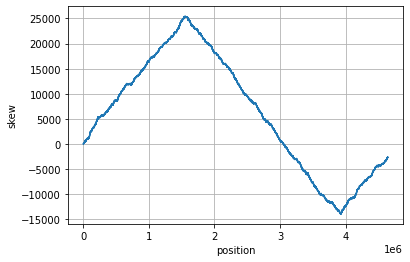

```python
fig, ax = plt.subplots()
ax.plot(range(len(e_coli_skew)), e_coli_skew)

ax.set(xlabel='position', ylabel='skew')
ax.grid()

plt.show()
```

Let's follow the 5' → 3' direction of DNA and walk along the chromosome from ter to ori (along a reverse half-strand), then continue on from ori to ter (along a forward half-strand). In our previous discussion, we saw that the skew is decreasing along the reverse half-strand and increasing along the forward half-strand. Thus, the skew should achieve a minimum at the position where the reverse half-strand ends and the forward half-strand begins, which is exactly the location of ori!

We have just developed an insight for a new algorithm for locating ori: it should be found where the skew attains a minimum.

#### Minimum Skew Problem

Find a position in a genome where the skew diagram attains a minimum.

- **Input:** A DNA string Genome.
- **Output:** All integer(s) i minimizing Skew[i] among all values of i (from 0 to len(Genome)).

```python
def MinimumSkew(Genome):
    """Find a position in a genome where the skew diagram attains a minimum

    Input -- a DNA string Genome.
    Output -- all integer i minimizing Skew_i(Genome) among all values of i (from 0 to |Genome|).
    """
    # generate an empty list positions
    positions = []
    # set a variable equal to SkewArray(Genome)
    skew = SkewArray(Genome)
    # find the minimum value of all values in the skew array
    min_val = min(skew)
    # range over the length of the skew array and add all positions achieving the min to positions
    for i in range(len(Genome)):
        if skew[i] == min_val:
            positions.append(i)
    return positions
```

```python
test_g = "TAAAGACTGCCGAGAGGCCAACACGAGTGCTAGAACGAGGGGCGTAAACGCGGGTCCGAT"

MinimumSkew(Genome=test_g)
```

```
[11, 24]
```

## Some Hidden Messages are More Elusive than Others

Solving the Minimum Skew Problem now provides us with an approximate location of ori at position 3923620 of E. coli. In an attempt to confirm this hypothesis, let's look for a hidden message representing a potential DnaA box near this location. Solving the Frequent Words Problem in a window of length 500 starting at position 3923620 (shown below) reveals no 9-mers (along with their reverse complements) that appear three or more times! Even if we have located ori in E. coli, it appears that we still have not found the DnaA boxes that jump-start replication in this bacterium

```
aatgatgatgacgtcaaaaggatccggataaaacatggtgattgcctcgc
ataacgcggtatgaaaatggattgaagcccgggccgtggattctactcaa
ctttgtcggcttgagaaagacctgggatcctgggtattaaaaagaagatc
tatttatttagagatctgttctattgtgatctcttattaggatcgcactg
ccctgtggataacaaggatccggcttttaagatcaacaacctggaaagga
tcattaactgtgaatgatcggtgatcctggaccgtataagctgggatcag
aatgaggggttatacacaactcaaaaactgaacaacagttgttctttgga
taactaccggttgatccaagcttcctgacagagttatccacagtagatcg
cacgatctgtatacttatttgagtaaattaacccacgatcccagccattc
ttctgccggatcttccggaatgtcgtgatcaagaatgttgatcttcagtg
```

Before we give up, let’s examine the ori of Vibrio cholerae one more time to see if it provides us with any insights on how to alter our algorithm to find DnaA boxes in E. coli. You may have noticed that in addition to the three occurrences of ATGATCAAG and three occurrences of its reverse complement CTTGATCAT, the Vibrio cholerae ori contains additional occurrences of ATGATCAAC and CATGATCAT, which differ from ATGATCAAG and CTTGATCAT in only a single nucleotide:

```
atcaATGATCAACgtaagcttctaagcATGATCAAGgtgctcacacagtttatccacaac
ctgagtggatgacatcaagataggtcgttgtatctccttcctctcgtactctcatgacca
cggaaagATGATCAAGagaggatgatttcttggccatatcgcaatgaatacttgtgactt
gtgcttccaattgacatcttcagcgccatattgcgctggccaaggtgacggagcgggatt
acgaaagCATGATCATggctgttgttctgtttatcttgttttgactgagacttgttagga
tagacggtttttcatcactgactagccaaagccttactctgcctgacatcgaccgtaaat
tgataatgaatttacatgcttccgcgacgatttacctCTTGATCATcgatccgattgaag
atcttcaattgttaattctcttgcctcgactcatagccatgatgagctCTTGATCATgtt
tccttaaccctctattttttacggaagaATGATCAAGctgctgctCTTGATCATcgtttc
```

Finding eight approximate occurrences of our target 9-mer and its reverse complement in a short region is even more statistically surprising than finding the six exact occurrences of ATGATCAAG and its reverse complement CTTGATCAT that we stumbled upon in the beginning of our investigation. Furthermore, the discovery of these approximate 9-mers makes sense biologically, since DnaA can bind not only to "perfect" DnaA boxes but to their slight variations as well.

We say that position i in k-mers p1 … pk and q1 … qk is a mismatch if pi ≠ qi. For example, CGAAT and CGGAC have two mismatches. The number of mismatches between strings p and q is called the Hamming distance between these strings and is denoted HammingDistance(p, q).

#### Hamming Distance Problem

Compute the Hamming distance between two strings.

- **Input:** Two strings of equal length.
- **Output:** The Hamming distance between these strings.

```python
def HammingDistance(p, q):
    """Returns Hamming distance between p and q"""
    distance = 0
    for i, j in zip(p, q):
        if i != j:
            distance +=1
    return distance
```

```python
HammingDistance("GGGCCGTTGGT", "GGACCGTTGAC")
```

```
3
```

```python
p = "TGGCTCAGCGTGTGAGGACCGATAATTAACGCGGCCGATGGGTTCTGTCCCGACACGCGT…"
q = "TTTTCAGTCTTATATTGCTGCTACTTACGCACGGTCCTGTGCCCGAAGGCCCTGGTGTAA…"

HammingDistance(p, q)
```

```
829
```

We say that a k-mer Pattern appears as a substring of Text with at most d mismatches if there is some k-mer substring Pattern' of Text having d or fewer mismatches with Pattern, i.e., HammingDistance(Pattern, Pattern') ≤ d. Our observation that a DnaA box may appear with slight variations leads to the following generalization of the Pattern Matching Problem.

#### Approximate Pattern Matching Problem

Find all approximate occurrences of a pattern in a string.

- **Input:** Strings Pattern and Text along with an integer d.
- **Output:** All starting positions where Pattern appears as a substring of Text with at most d mismatches.

```python
def ApproximatePatternMatching(Text, Pattern, d):
    """Returns a list with all starting positions where Pattern
    appears as a substring of Text with at most d mismatches."""
    positions = []
    for i in range(len(Text)-len(Pattern)+1):
        if HammingDistance(Text[i:i+len(Pattern)], Pattern) <= d:
            positions.append(i)
    return positions
```

```python
ApproximatePatternMatching(Text="CGCCCGAATCCAGAACGCATTCCCATATTTCGGGACCACTGGCCTCCACGGTACGGACGTCAATCAAAT",
                           Pattern="ATTCTGGA", d=3)
```

```
[6, 7, 26, 27]
```

```python
d = 6
Pattern = "CCCGGCCCAAT"
Text = "CAGACCGTCGTTCCCTGCCAGACCCCATATTCGTGCTCACAGGTAGTTTAATCCCCCGCC…"

pos = ApproximatePatternMatching(Text, Pattern, d)
print(" ".join([str(i) for i in pos]))
```

```
11 12 13 16 17 18 30 51 52 53 54 58 66 67 68 72 73 87 88 118 134 139 178 179 196 208 209 222 228 229 237 243 252 269 270 280 285 286 289 305 306 331 339 370 382 383 403 412 413 414 437 475 476 480 481 490 491 492 503 504 505 509 519 520 526 532 533 539 540 568 599 609 614 623 628 642 656 657 670 680…
```

#### ApproximatePatternCount

Our goal now is to modify our previous algorithm for the Frequent Words Problem in order to find DnaA boxes by identifying frequent k-mers, possibly with mismatches. Given strings Text and Pattern as well as an integer d, we define Count_d(Text, Pattern) as the total number of occurrences of Pattern in Text with at most d mismatches. For example, Count_1(AACAAGCTGATAAACATTTAAAGAG, AAAAA) = 4 because AAAAA appears four times in this string with at most one mismatch: AACAA, ATAAA, AAACA, and AAAGA. Note that two of these occurrences overlap.

```python
def Count_d(Text, Pattern, d):
    """Computes the number of occurrences of Pattern in Text
    with at most d mismatches"""
    count = 0
    for i in range(len(Text)-len(Pattern)+1):
        if HammingDistance(Text[i:i+len(Pattern)], Pattern) <= d:
            count += 1
    return count
```

```python
Count_d(Text="TTTAGAGCCTTCAGAGG", Pattern="GAGG", d=2)
```

```
4
```

```python
Count_d(Text="AACAAGCTGATAAACATTTAAAGAG", Pattern="AAAAA", d=2)
```

```
11
```

Computing Countd(Text, Pattern) simply requires us to compute the Hamming distance between Pattern and every k-mer substring of Text, which is achieved by the following pseudocode.

```
    ApproximatePatternCount(Text, Pattern, d)
        count ← 0
        for i ← 0 to |Text| − |Pattern|
            Pattern′ ← Text(i , |Pattern|)
            if HammingDistance(Pattern, Pattern′) ≤ d
                count ← count + 1
        return count
```

```python
d=3
Pattern="TTTGA"
Text="ATCCGGTCCTAGTACACAGAGGAATCATGGCTGATATTCCTGGCCTAATTCGTGTATCGC…"

Count_d(Text, Pattern, d)
```

```
115
```

A most frequent k-mer with up to d mismatches in Text is simply a string Pattern maximizing Countd(Text, Pattern) among all k-mers. Note that Pattern does not need to actually appear as a substring of Text; for example, as we already saw, AAAAA is the most frequent 5-mer with 1 mismatch in AACAAGCTGATAAACATTTAAAGAG, even though it does not appear exactly in this string. Keep this in mind while solving the following problem.

#### Frequent Words with Mismatches Problem

Find the most frequent k-mers with mismatches in a string

- **Input:** A string Text as well as integers k and d. (You may assume k ≤ 12 and d ≤ 3.)
- **Output:** All most frequent k-mers with up to d mismatches in Text.

One way to solve the above problem is to generate all 4k k-mers Pattern, compute ApproximatePatternCount(Text, Pattern, d) for each k-mer Pattern, and then output k-mers with the maximum number of approximate occurrences. This is an inefficient approach in practice, since many of the 4k k-mers should not be considered because neither they nor their mutated versions (with up to d mismatches) appear in Text.

We now redefine the Frequent Words Problem to account for both mismatches and reverse complements. Recall that Patternrc refers to the reverse complement of Pattern.

#### Frequent Words with Mismatches and Reverse Complements Problem

Find the most frequent k-mers (with mismatches and reverse complements) in a string.

- **Input:** A DNA string Text as well as integers k and d.
- **Output:** All k-mers Pattern maximizing the sum Countd(Text, Pattern)+ Countd(Text, Patternrc) over all possible k-mers.

## A Final Attempt at Finding DnaA Boxes in E. coli

We now make a final attempt to find DnaA boxes in E. coli by finding the most frequent 9-mers with mismatches and reverse complements in the region suggested by the minimum skew as ori. Although the minimum of the skew diagram for E. coli is found at position 3923620, we should not assume that its ori is found exactly at this position due to random fluctuations in the skew. To remedy this issue, we could choose a larger window size (e.g., L = 1000), but expanding the window introduces the risk that we may bring in other clumped 9-mers that do not represent DnaA boxes but appear in this window more often than the true DnaA box. It makes more sense to try a small window either starting, ending, or centered at the position of minimum skew.

Let’s cross our fingers and identify the most frequent 9-mers (with 1 mismatch and reverse complements) within a window of length 500 starting at position 3923620 of the E. coli genome. Bingo! The experimentally confirmed DnaA box in E. coli (TTATCCACA) is indeed a most frequent 9-mer with 1 mismatch, along with its reverse complement TGTGGATAA:

```
aatgatgatgacgtcaaaaggatccggataaaacatggtgattgcctcgc
ataacgcggtatgaaaatggattgaagcccgggccgtggattctactcaa
ctttgtcggcttgagaaagacctgggatcctgggtattaaaaagaagatc
tatttatttagagatctgttctattgtgatctcttattaggatcgcactg
cccTGTGGATAAcaaggatccggcttttaagatcaacaacctggaaagga
tcattaactgtgaatgatcggtgatcctggaccgtataagctgggatcag
aatgaggggTTATACACAactcaaaaactgaacaacagttgttcTTTGGA
TAActaccggttgatccaagcttcctgacagagTTATCCACAgtagatcg
cacgatctgtatacttatttgagtaaattaacccacgatcccagccattc
ttctgccggatcttccggaatgtcgtgatcaagaatgttgatcttcagtg
```

You will notice that we emphasized a large part of this sequence with bold text. This region is the experimentally verified ori of E. coli, which starts 37 nucleotides after position 3923620, where the skew reaches its minimum value.

We were very fortunate that the DnaA boxes of E. coli are captured in the window that we chose. Moreover, while TTATCCACA represents a most frequent 9-mer with 1 mismatch and reverse complements in this 500-nucleotide window, it is not the only one: GGATCCTGG, GATCCCAGC, GTTATCCAC, AGCTGGGAT, and CTGGGATCA also appear 4 times with 1 mismatch and reverse complements.

We do not know what purpose — if any — these other 9-mers serve in the E. coli genome, but we do know that there are many different types of hidden messages in genomes; these hidden messages have a tendency to cluster within a genome, and most of them have nothing to do with replication. One example is the regulatory DNA motifs responsible for gene expression that we will study soon. The important lesson is that existing approaches to ori prediction remain imperfect and are sometimes inconclusive. However, even providing biologists with a small collection of 9-mers as candidate DnaA boxes is a great aid as long as one of these 9-mers is correct.

Thus, **the moral of this chapter is that even though computational predictions can be powerful, bioinformaticians should collaborate with biologists to verify their computational predictions**. Or improve these predictions: the next question hints at how ori predictions can be carried out using comparative genomics, a bioinformatics approach that uses evolutionary similarities to answer difficult questions about genomes.

## Complications in ori Predictions

In this chapter, we have considered three genomes and found three different hypothesized 9-mers encoding ATGATCAAG in Vibrio cholerae, CCTACCACC in Thermotoga petrophila, and TTATCCACA in E. coli. We must warn you that finding ori is often more complex than in the three examples we considered. Some bacteria have even fewer DnaA boxes than E. coli, making it difficult to identify them. The ter region is often located not directly opposite to ori but may be significantly shifted, resulting in reverse and forward half-strands having substantially different lengths. The position of the skew minimum is often only a rough indicator of ori position, which forces researchers to expand their windows when searching for DnaA boxes, bringing in extraneous repeated substrings. Finally, skew diagrams do not always look as nice as that of E. coli; for example, the skew diagram for Thermotoga petrophila is shown below.

[figure not shown]

## Bibliography Notes

Using the skew to find replication origins was first proposed by Lobry, 1996 and also described in Grigoriev, 1998. Grigoriev, 2011 provides an excellent introduction to the skew approach, and Sernova and Gelfand, 2008 gave a review of algorithms and software tools for finding replication origins in bacteria. Lundgren et al., 2004 demonstrated that archaea may have multiple ori. Wang et al., 2011 inserted an artificial ori into the E. coli genome and showed that it triggers replication. Xia, 2012 was the first to conjecture that bacteria may have multiple replication origins. Gao and Zhang, 2008 developed the Ori-Finder software program for finding bacterial replication origins.

Liachko et al., 2013 provided the most comprehensive description of the replication originsofyeast. Solov’ev, 1966 was the first to derive accurate formulas for approximating the probabilities of patterns in a string. Gardner, 1974 wrote an excellent introductory article about the Best Bet for Simpletons paradox. Guibas and Odlyzko, 1981 provided an excellent coverage of the overlapping words paradox that illustrates the complexity of computing the probabilities of patterns in a random text. They also derived a rather complicated proof of Conway’s formula for Best Bet for Simpletons. Sedgewick and Flajolet, 2013 gave an overview of various approaches for computing the probabilities of patterns in a string.